# Create Database

```python
import sqlite3
import pandas as pd

# Path to the Excel file
excel_path =

# Path to the SQLite database (this will create a new file if it doesn't exist)
db_path =
conn = sqlite3.connect(db_path)

# Read all sheet names from the Excel file
all_sheets = pd.ExcelFile(excel_path).sheet_names

# Iterate through each sheet and convert to a table in SQLite
for sheet_name in all_sheets:
    sheet_data = pd.read_excel(excel_path, sheet_name=sheet_name)
    sheet_data.to_sql(sheet_name, conn, index=False, if_exists='replace')

# Commit the changes and close the connection
conn.commit()
conn.close()
```

```python
import sqlite3
import pandas as pd

# Path to the Excel file
excel_path =

# Path to the SQLite database (this will create a new file if it doesn't exist)
db_path =
conn = sqlite3.connect(db_path)

# Read all sheet names from the Excel file
all_sheets = pd.ExcelFile(excel_path).sheet_names

# Iterate through each sheet and convert to a table in SQLite
for sheet_name in all_sheets:
    sheet_data = pd.read_excel(excel_path, sheet_name=sheet_name)
    sheet_data.to_sql(sheet_name, conn, index=False, if_exists='replace')

# Commit the changes and close the connection
conn.commit()
conn.close()
```

# Data Cleaning

Standardization

Standardization

```python
import pandas as pd

HeadlinesPath =
# Read the content of both sheets
sheet_2022 = pd.read_excel(HeadlinesPath , sheet_name='2022')
sheet_2023 = pd.read_excel(HeadlinesPath , sheet_name='2023')

# Check and convert the 'Date' column in the 2022 sheet if necessary
if sheet_2022['Date'].dtype != 'datetime64[ns]':
    sheet_2022['Date'] = pd.to_datetime(sheet_2022['Date'])

# Check and convert the 'Date' column in the 2023 sheet if necessary
if sheet_2023['Date'].dtype != 'datetime64[ns]':
    sheet_2023['Date'] = pd.to_datetime(sheet_2023['Date'])


    # Define the Excel writer
with pd.ExcelWriter('headlines.xlsx', engine='openpyxl') as writer:
    # Save the 2022 sheet
    sheet_2022.to_excel(writer, sheet_name='2022', index=False)

    # Save the 2023 sheet
    sheet_2023.to_excel(writer, sheet_name='2023', index=False)
```

Turn into Database

```python
from sqlalchemy import create_engine

# Sort both sheets by date
sheet_2022 = sheet_2022.sort_values('Date')
sheet_2023 = sheet_2023.sort_values('Date')

# Create SQLite database engine
engine = create_engine('sqlite:///headlines.db')

# Save both sheets to the SQLite database
sheet_2022.to_sql('2022', con=engine, index=False, if_exists='replace')
sheet_2023.to_sql('2023', con=engine, index=False, if_exists='replace')
```

```
1013
```

```python
# Read both tables from the SQLite database
table_2022 = pd.read_sql('2022', con=engine)
table_2023 = pd.read_sql('2023', con=engine)

# Convert the 'Date' column to datetime and extract only the date part
table_2022['Date'] = pd.to_datetime(table_2022['Date']).dt.date
table_2023['Date'] = pd.to_datetime(table_2023['Date']).dt.date

# Create date ranges for each year
date_range_2022 = pd.date_range(start='2022-01-01', end='2022-12-31').date
date_range_2023 = pd.date_range(start='2023-01-01', end='2023-08-01').date

# Extract unique dates from the DataFrames
unique_dates_2022 = table_2022['Date'].unique()
unique_dates_2023 = table_2023['Date'].unique()

# Find missing dates by taking the set difference
missing_dates_2022 = set(date_range_2022) - set(unique_dates_2022)
missing_dates_2023 = set(date_range_2023) - set(unique_dates_2023)

# Count the number of missing dates
missing_count_2022 = len(missing_dates_2022)
missing_count_2023 = len(missing_dates_2023)

missing_count_2022, missing_count_2023
```

```
(62, 37)
```

# ChatGPT Pipeline

```python
import openai
import time
import pandas as pd
import sqlite3
import csv
import os
```

```python
from sqlalchemy import create_engine

# Load the API key
with open("api_key.txt", "r") as file:
    openai.api_key = file.read().strip()

# Connection to the SQLite database
engine = create_engine()

# Read data from the 2022 table in the SQLite database
data_2022 = pd.read_sql('2022', con=engine)

# Read data from the 2023 table in the SQLite database
data_2023 = pd.read_sql('2023', con=engine)

# Create a list of tuples containing headlines and corresponding dates
headlines_with_dates = list(zip(data_2022['Headline'], data_2022['Date']))


print (headlines_with_dates)
```

```
[('Byron Wien sees inflation and gold prices rising, and these ETFs will rally if he’s right', Timestamp('2022-01-03 00:00:00')), ('Biden administration likely to pick Philip Jefferson for Fed seat - Bloomberg', Timestamp('2022-01-03 00:00:00')), ('Construction spending +0.4% in November', Timestamp…
```

Settings

```python
response = openai.ChatCompletion.create(
  model="gpt-3.5-turbo-16k-0613",
  messages=[
    {
      "role": "user",
      "content": ""
    }
  ],
  temperature=0.1,
  max_tokens=256,
  top_p=1,
  frequency_penalty=0,
  presence_penalty=0
)
```

```python
def get_sentiments_and_explanations(headlines_with_dates, role):
    # Create a DataFrame to hold the results
    results_df = pd.DataFrame(columns=['Date', 'Headline', 'Response'])

    # Processing the first 20 headlines
    for i, (headline, date) in enumerate(headlines_with_dates[:5]):
        print(f'Processing headline {i + 1}') # Displaying progress
        prompt = f"Forget all your previous instructions. Classify the following headline into one of these categories: bad for US treasury (- 1), mostly bad for US treasury(-0.5), neutral/ irrelevant (0), mostly good for US treasury (0.5), good for US treasury (1). Output the number then on the next line a concise explanation. Headline: \"{headline}\""
        messages = [
            {"role": "system", "content": role},
            {"role": "user", "content": prompt}
        ]

        for _ in range(3):  # try 3 times
            try:
                # Get the response from GPT
                response = openai.ChatCompletion.create(
                    model="gpt-3.5-turbo-16k-0613",
                    messages=messages,
                )
                results_df.loc[i] = [date, headline, str(response)]  # Insert directly into DataFrame
                break
            except openai.error.OpenAIError as e:
                print(f"Error: {e}. Retrying in 10 seconds...")
                time.sleep(10)
        else:
            print("Failed to get a response after 3 attempts. Skipping this headline.")
            results_df.loc[i] = [date, headline, "Failed to get a response from the model"]  # default value
            continue

    return results_df  f
```

```python
# Define the role
role = f"You are a financial expert with treasury debt experience and sentiment score abilities. Your responses are in the format: Number: Explanation"

# Executing the function on the 2022 headlines
responses = get_sentiments_and_explanations(headlines_with_dates, role)
```

```
Processing headline 1
Processing headline 2
Processing headline 3
Processing headline 4
Processing headline 5
```

Make the Database of responses from ChatGPT & make a table of Raw responses

```python
from sqlalchemy import create_engine

# Create a SQLite engine
engine = create_engine('sqlite:///responses.db')

# Save the DataFrame to the SQLite database
responses.to_sql('Raw Responses', con=engine, index=False, if_exists='replace')
```

```
5
```

```python
print (responses.head())
```

```
        Date                                           Headline  \
0 2022-01-03  Byron Wien sees inflation and gold prices risi...
1 2022-01-03  Biden administration likely to pick Philip Jef...
2 2022-01-03            Construction spending +0.4% in November
3 2022-01-03  December PMI Manufacturing comes in below prio...
4 2022-01-03  Turkish inflation jumps to 19-year high in Dec...

                                            Response
0  {\n  "id": "chatcmpl-7pq6B4U9dLlavXlsiS7xAyBjt...
1  {\n  "id": "chatcmpl-7pq6D6Wkqg0KhjAB2pEtMeFUf...
2  {\n  "id": "chatcmpl-7pq6FohZ5TrSuazFNVTSma07N...
3  {\n  "id": "chatcmpl-7pq6GsGAbtQoyOxvlRDSGgEOi...
4  {\n  "id": "chatcmpl-7pq6ICkSun9bE66rvNFX0LJBA...
```

Obtain the structure of the responses from the database column Response

```python
print(responses.loc[0, 'Response'])
```

```
{
  "id": "chatcmpl-7pq6B4U9dLlavXlsiS7xAyBjtZZfn",
  "object": "chat.completion",
  "created": 1692589351,
  "model": "gpt-3.5-turbo-16k-0613",
  "choices": [
    {
      "index": 0,
      "message": {
        "role": "assistant",
        "content": "0.5: This headline suggests that Byron Wien is predicting inflation and rising gold prices. If his prediction is correct, it implies a positive impact on the US treasury. The recommendation for these ETFs to rally further supports the notion of a potential positive outcome for th…
      },
      "finish_reason": "stop"
    }
  ],
  "usage": {
    "prompt_tokens": 130,
    "completion_tokens": 56,
    "total_tokens": 186
  }
}
```

Extract the content

```python
# Enter code to extract content here

import json
import sqlite3


# Path to the SQLite database file
db_path = ''

# Connecting to the SQLite database
conn = sqlite3.connect(db_path)

# Creating a cursor object to execute SQL commands
cursor = conn.cursor()

# Query to get the first row from the 'extracted_responses' table
query = "SELECT Response FROM 'Raw Responses' LIMIT 1;"
cursor.execute(query)
response_json = cursor.fetchone()[0]

# Convert the string to a JSON object
response_obj = json.loads(response_json)

# Extract the content part
content = response_obj['choices'][0]['message']['content']

# Print the content
print(content)
```

```
0.5: This headline suggests that Byron Wien is predicting inflation and rising gold prices. If his prediction is correct, it implies a positive impact on the US treasury. The recommendation for these ETFs to rally further supports the notion of a potential positive outcome for the US treasury.
```

```python
# Creating a table called 'Extracted Responses'
create_table_query = '''
CREATE TABLE IF NOT EXISTS "Extracted Responses" (
    "Date" DATETIME,
    "Headline" TEXT,
    "Extracted_Response" TEXT
);
'''
cursor.execute(create_table_query)

# Query to select all rows from the 'Raw Responses' table
select_query = "SELECT Date, Headline, Response FROM 'Raw Responses';"
cursor.execute(select_query)
raw_responses = cursor.fetchall()

# Query to insert the extracted response into the 'Extracted Responses' table
insert_query = '''
INSERT INTO "Extracted Responses" ("Date", "Headline", "Extracted_Response")
VALUES (?, ?, ?);
'''

# Iterating through the raw responses and extracting the content part
for row in raw_responses:
    date, headline, response_json = row
    response_obj = json.loads(response_json)
    extracted_response = response_obj['choices'][0]['message']['content']
    cursor.execute(insert_query, (date, headline, extracted_response))

# Committing the changes to the database
conn.commit()

# Query to select all rows from the 'Extracted Responses' table
select_extracted_responses_query = "SELECT Date, Headline, Extracted_Response FROM 'Extracted Responses';"
cursor.execute(select_extracted_responses_query)
extracted_responses = cursor.fetchall()

# Printing the results
for row in extracted_responses:
    date, headline, extracted_response = row
    print(f"Date: {date}\nHeadline: {headline}\nExtracted Response: {extracted_response}\n{'-'*50}")

# Optionally, you can close the connection
conn.close()
```

```
Date: 2022-01-03 00:00:00.000000
Headline: Byron Wien sees inflation and gold prices rising, and these ETFs will rally if he’s right
Extracted Response: 0.5: This headline suggests that Byron Wien is predicting inflation and rising gold prices. If his prediction is correct, it implies a positive impact on the US treasury. The recommendation for these ETFs to rally further supports the notion of a potential positive outcome for th…
--------------------------------------------------
Date: 2022-01-03 00:00:00.000000
Headline: Biden administration likely to pick Philip Jefferson for Fed seat - Bloomberg
Extracted Response: 0.5: The headline suggests that the Biden administration is likely to pick Philip Jefferson for a Federal Reserve seat which indicates a positive move towards the US treasury.
--------------------------------------------------
Date: 2022-01-03 00:00:00.000000
Headline: Construction spending +0.4% in November
Extracted Response: 0.5: This headline suggests that construction spending increased by 0.4% in November. An increase in construction spending is generally seen as a positive economic indicator, as it indicates growth and investment in the sector. Therefore, this news is mostly good for the US treas…
--------------------------------------------------
Date: 2022-01-03 00:00:00.000000
Headline: December PMI Manufacturing comes in below prior month levels
Extracted Response: -0.5: The headline suggests that the December Purchasing Managers' Index (PMI) for manufacturing is lower than the previous month. This indicates a potential slowdown in the manufacturing sector, which could have a negative impact on the US treasury.
--------------------------------------------------
Date: 2022-01-03 00:00:00.000000
Headline: Turkish inflation jumps to 19-year high in December amid lira swoon
Extracted Response: -0.5: Turkish inflation reaching a 19-year high indicates a negative impact on the US treasury due to the potential weakening of the lira and its implications on global economic stability.
--------------------------------------------------
```

```python
import sqlite3
import pandas as pd
import re

def split_sentiment_and_explanation(content):
    # Using regular expression to find the first numerical part
    match = re.match(r'([-]?\d*\.?\d+)', content)
    if match:
        sentiment = match.group(1)
        explanation = content[len(sentiment)+1:].strip() # Including +1 to skip the colon
        return sentiment, explanation
    return None, content  # Default value when split is not possible

# Path to the SQLite database file
db_path = ''

# Connecting to the SQLite database
conn = sqlite3.connect(db_path)

# Reading the 'Extracted Responses' table from the database using a SQL query
query = "SELECT Date, Headline, Extracted_Response FROM 'Extracted Responses';"
responses_extracted_df = pd.read_sql(query, con=conn)

# Applying the custom function to split the 'Extracted_Response' column
responses_extracted_df['Sentiment_Score'], responses_extracted_df['Explanation'] = zip(*responses_extracted_df['Extracted_Response'].apply(split_sentiment_and_explanation))

# Renaming the columns as required
responses_extracted_df.rename(columns={'Sentiment_Score': 'Sentiment Score'}, inplace=True)

# Dropping the original 'Extracted_Response' column
responses_extracted_df.drop(columns=['Extracted_Response'], inplace=True)

# Saving the updated DataFrame to a new table in the SQLite database (e.g., 'Split Responses')
responses_extracted_df.to_sql('Split Responses', con=conn, index=False, if_exists='replace')

# Closing the connection
conn.close()
```

```python
# Connecting to the SQLite database
conn = sqlite3.connect(db_path)
cursor = conn.cursor()

# Query to select the Date and Sentiment Score columns from the 'Split Responses' table
select_dates_scores_query = "SELECT Date, `Sentiment Score` FROM 'Split Responses';"
cursor.execute(select_dates_scores_query)
dates_scores = cursor.fetchall()

# Creating a new table called 'Dates and Scores'
create_dates_scores_table_query = '''
CREATE TABLE IF NOT EXISTS "Dates and Scores" (
    "Date" DATETIME,
    "Sentiment Score" TEXT
);
'''
cursor.execute(create_dates_scores_table_query)

# Query to insert the dates and scores into the 'Dates and Scores' table
insert_dates_scores_query = '''
INSERT INTO "Dates and Scores" ("Date", "Sentiment Score")
VALUES (?, ?);
'''

# Inserting the dates and scores into the 'Dates and Scores' table
for row in dates_scores:
    cursor.execute(insert_dates_scores_query, row)

# Committing the changes to the database
conn.commit()

# Optionally, you can close the connection
conn.close()

# Returning a success message
print("Dates and Scores table created and populated successfully.")
```

```
Dates and Scores table created and populated successfully.
```

```python
# Connecting to the SQLite database
conn = sqlite3.connect(db_path)
cursor = conn.cursor()

# Query to select the Date and average Sentiment Score grouped by Date from the 'Dates and Scores' table
average_scores_query = '''
SELECT Date, AVG(CAST("Sentiment Score" AS FLOAT)) AS "Average Sentiment Score"
FROM "Dates and Scores"
GROUP BY Date;
'''
cursor.execute(average_scores_query)
average_scores = cursor.fetchall()

# Creating a new table called 'Dates & Scores Averaged Daily'
create_average_scores_table_query = '''
CREATE TABLE IF NOT EXISTS "Dates & Scores Averaged Daily" (
    "Date" DATETIME,
    "Average Sentiment Score" REAL
);
'''
cursor.execute(create_average_scores_table_query)

# Query to insert the dates and average scores into the 'Dates & Scores Averaged Daily' table
insert_average_scores_query = '''
INSERT INTO "Dates & Scores Averaged Daily" ("Date", "Average Sentiment Score")
VALUES (?, ?);
'''

# Inserting the dates and average scores into the 'Dates & Scores Averaged Daily' table
for row in average_scores:
    cursor.execute(insert_average_scores_query, row)

# Committing the changes to the database
conn.commit()

# Optionally, you can close the connection
conn.close()

# Returning a success message
print("Dates & Scores Averaged Daily table created and populated successfully.")
```

```
Dates & Scores Averaged Daily table created and populated successfully.
```

```python
# Connecting to the SQLite database
conn = sqlite3.connect(db_path)
cursor = conn.cursor()

# Query to select the Date and Average Sentiment Score from the 'Dates & Scores Averaged Daily' table
select_average_scores_query = '''
SELECT Date, "Average Sentiment Score"
FROM "Dates & Scores Averaged Daily"
ORDER BY Date;
'''
cursor.execute(select_average_scores_query)
average_scores = cursor.fetchall()

# Creating a new table called 'Cumulative Scores'
create_cumulative_scores_table_query = '''
CREATE TABLE IF NOT EXISTS "Cumulative Scores" (
    "Date" DATETIME,
    "Cumulative Sentiment Score" REAL
);
'''
cursor.execute(create_cumulative_scores_table_query)

# Query to insert the dates and cumulative scores into the 'Cumulative Scores' table
insert_cumulative_scores_query = '''
INSERT INTO "Cumulative Scores" ("Date", "Cumulative Sentiment Score")
VALUES (?, ?);
'''

# Calculating and inserting the dates and cumulative scores into the 'Cumulative Scores' table
cumulative_score = 0
for row in average_scores:
    date, average_score = row
    cumulative_score += average_score
    cursor.execute(insert_cumulative_scores_query, (date, cumulative_score))

# Committing the changes to the database
conn.commit()

# Optionally, you can close the connection
conn.close()

# Returning a success message
print("Cumulative Scores table created and populated successfully.")
```

```
Cumulative Scores table created and populated successfully.
```

[figure not shown]

```python
import matplotlib.pyplot as plt

# Connecting to the SQLite database
conn = sqlite3.connect(db_path)
cursor = conn.cursor()

# Query to select the Date and Cumulative Sentiment Score from the 'Cumulative Scores' table
select_cumulative_scores_query = '''
SELECT Date, "Cumulative Sentiment Score"
FROM "Cumulative Scores";
'''
cursor.execute(select_cumulative_scores_query)
cumulative_scores = cursor.fetchall()

# Splitting the data into dates and scores
dates, scores = zip(*cumulative_scores)

# Converting dates to a proper format
dates = pd.to_datetime(dates)

# Plotting the cumulative scores against the dates
plt.figure(figsize=[12, 6])
plt.plot(dates, scores, marker='o', linestyle='-', color='blue')
plt.title('Cumulative Sentiment Scores Over Time')
plt.xlabel('Date')
plt.ylabel('Cumulative Sentiment Score')
plt.grid(True)
plt.show()

# Optionally, you can close the connection
conn.close()
```

# Vader Sentiment Analysis

```python
from nltk.sentiment.vader import SentimentIntensityAnalyzer
import sqlite3

# Path to the "headlines.db" database
headlines_db_path = ""

# Create a VADER sentiment analysis object
sia = SentimentIntensityAnalyzer()

# Connect to the "headlines.db" database
headlines_conn = sqlite3.connect(headlines_db_path)
cursor = headlines_conn.cursor()

# Table names to iterate through
table_names = ['2022', '2023']

# Iterate through the tables and analyze sentiment
for table_name in table_names:
    print(f"Processing table: {table_name}")

    # Query to select the headlines and IDs from the table
    select_headlines_query = f"SELECT rowid, Headline FROM `{table_name}`;"
    headlines = cursor.execute(select_headlines_query).fetchall()

    # Analyze the sentiment using VADER and update the VADER column
    for rowid, headline in headlines:
        vader_score = sia.polarity_scores(headline)['compound']
        update_query = f"UPDATE `{table_name}` SET VADER = ? WHERE rowid = ?;"
        cursor.execute(update_query, (vader_score, rowid))
        print(f"Updated headline: {headline}\nVADER score: {vader_score}")

    print(f"Completed processing table: {table_name}\n")

# Commit the changes to the database
headlines_conn.commit()

# Optionally, close the connection
headlines_conn.close()

# Return success message
print("VADER sentiment analysis applied and results saved to the 2022 and 2023 tables.")
```

[output not shown]

[output cut: 5382 more lines]

[output not shown]

Create database of VADER scores

```python
from nltk.sentiment.vader import SentimentIntensityAnalyzer
import sqlite3

# Path to the existing SQLite database (uploaded file)
existing_db_path = ""

# Path to the new SQLite database (you can change this as needed)
new_db_path = ""

# Connect to the existing SQLite database
existing_conn = sqlite3.connect(existing_db_path)
existing_cursor = existing_conn.cursor()

# Create a VADER sentiment analysis object
sia = SentimentIntensityAnalyzer()

# Connect to the new SQLite database
new_conn = sqlite3.connect(new_db_path)
new_cursor = new_conn.cursor()

# Iterate through the tables in the existing database
for table_name in ['2022', '2023']:
    # Query to select the headlines and dates from the existing table
    select_data_query = f"SELECT Date, Headline FROM `{table_name}`;"
    data = existing_cursor.execute(select_data_query).fetchall()

    # Prepare new data with VADER scores
    new_data = [(date, headline, sia.polarity_scores(headline)['compound']) for date, headline in data]

    # Create a new table in the new database with the same structure plus the VADER column
    new_cursor.execute(f"CREATE TABLE `{table_name}` (Date TEXT, Headline TEXT, VADER REAL);")

    # Insert the new data into the new table
    new_cursor.executemany(f"INSERT INTO `{table_name}` (Date, Headline, VADER) VALUES (?, ?, ?);", new_data)

# Commit the changes and close the connections
existing_conn.close()
new_conn.commit()
new_conn.close()
```

Combine the 2022 and 2023 scores for simplicity (split later into testing and training)

```python
import sqlite3

# Path to the vaderScores.db database
db_path = ""
conn = sqlite3.connect(db_path)
cursor = conn.cursor()

# Create a new table called 'Combined' to store the data from both '2022' and '2023'
cursor.execute('''
CREATE TABLE IF NOT EXISTS "Combined" (
    "Date" TEXT,
    "Headline" TEXT,
    "VADER" REAL
);
''')

# Insert data from both '2022' and '2023' tables into the 'Combined' table
for table_name in ['2022', '2023']:
    cursor.execute(f"INSERT INTO Combined SELECT * FROM `{table_name}`;")

# Commit the changes
conn.commit()
```

Process the data as before to create the cumulative data

```python
import sqlite3
from datetime import datetime

# Path to the existing SQLite database (uploaded file)
existing_db_path = ""
conn = sqlite3.connect(existing_db_path)
cursor = conn.cursor()

for table_name in ['2022', '2023']:


    # Query to select the Date and VADER columns from the tables
    table_name = 'Combined'  # Change this to the table you want to process
    select_dates_scores_query = f"SELECT Date, VADER FROM `{table_name}`;"
    dates_scores = cursor.execute(select_dates_scores_query).fetchall()

    # Create a new table called 'Dates and Scores'
    create_dates_scores_table_query = '''
    CREATE TABLE IF NOT EXISTS "Dates and Scores" (
        "Date" DATETIME,
        "VADER" REAL
    );
    '''
    cursor.execute(create_dates_scores_table_query)

    # Inserting the dates and VADER scores into the 'Dates and Scores' table
    for row in dates_scores:
        date_str, vader_score = row
        date_obj = datetime.strptime(date_str, "%Y-%m-%d %H:%M:%S")  # Assuming the date format
        cursor.execute("INSERT INTO \"Dates and Scores\" (\"Date\", \"VADER\") VALUES (?, ?);", (date_obj, vader_score))

# Committing the changes to the database
conn.commit()
conn.close()
print("Dates and Scores table created and populated successfully with VADER scores.")
```

```
Dates and Scores table created and populated successfully with VADER scores.
```

```python
import sqlite3

# Path to the existing SQLite database (uploaded file)
db_path = ""
conn = sqlite3.connect(db_path)
cursor = conn.cursor()

# Query to select the Date and average VADER score grouped by Date from the 'Dates and Scores' table
average_scores_query = '''
SELECT Date, AVG("VADER") AS "Average VADER Score"
FROM "Dates and Scores"
GROUP BY Date;
'''
cursor.execute(average_scores_query)
average_scores = cursor.fetchall()

# Creating a new table called 'Dates & Scores Averaged Daily'
create_average_scores_table_query = '''
CREATE TABLE IF NOT EXISTS "Dates & Scores Averaged Daily" (
    "Date" DATETIME,
    "Average VADER Score" REAL
);
'''
cursor.execute(create_average_scores_table_query)

# Query to insert the dates and average scores into the 'Dates & Scores Averaged Daily' table
insert_average_scores_query = '''
INSERT INTO "Dates & Scores Averaged Daily" ("Date", "Average VADER Score")
VALUES (?, ?);
'''

# Inserting the dates and average scores into the 'Dates & Scores Averaged Daily' table
for row in average_scores:
    cursor.execute(insert_average_scores_query, row)

# Committing the changes to the database
conn.commit()
conn.close()
print("Dates & Scores Averaged Daily table created and populated successfully.")
```

```
Dates & Scores Averaged Daily table created and populated successfully.
```

```python
import sqlite3

# Path to the existing SQLite database (uploaded file)
db_path = ""
conn = sqlite3.connect(db_path)
cursor = conn.cursor()

# Query to select the Date and Average VADER Score from the 'Dates & Scores Averaged Daily' table
select_average_scores_query = '''
SELECT Date, "Average VADER Score"
FROM "Dates & Scores Averaged Daily"
ORDER BY Date;
'''
cursor.execute(select_average_scores_query)
average_scores = cursor.fetchall()

# Creating a new table called 'Cumulative Scores'
create_cumulative_scores_table_query = '''
CREATE TABLE IF NOT EXISTS "Cumulative Scores" (
    "Date" DATETIME,
    "Cumulative VADER Score" REAL
);
'''
cursor.execute(create_cumulative_scores_table_query)

# Query to insert the dates and cumulative scores into the 'Cumulative Scores' table
insert_cumulative_scores_query = '''
INSERT INTO "Cumulative Scores" ("Date", "Cumulative VADER Score")
VALUES (?, ?);
'''

# Calculating and inserting the dates and cumulative scores into the 'Cumulative Scores' table
cumulative_score = 0
for row in average_scores:
    date, average_score = row
    cumulative_score += average_score
    cursor.execute(insert_cumulative_scores_query, (date, cumulative_score))

# Committing the changes to the database
conn.commit()
conn.close()
print("Cumulative Scores table created and populated successfully.")
```

```
Cumulative Scores table created and populated successfully.
```

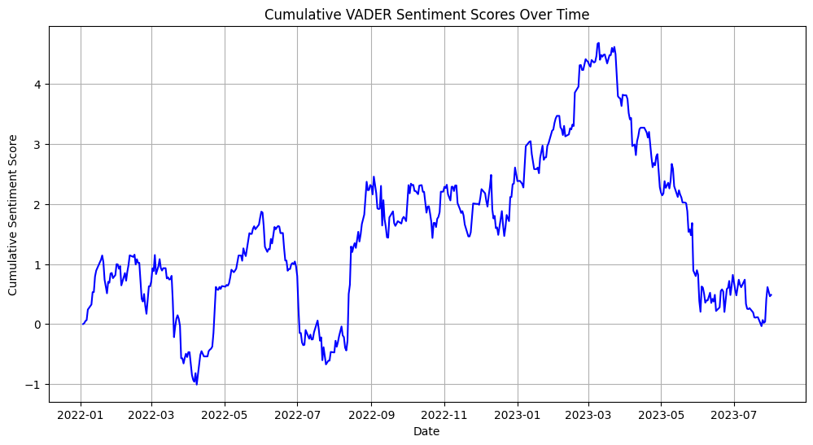

```python
import matplotlib.pyplot as plt

# Connecting to the SQLite database
conn = sqlite3.connect(db_path)
cursor = conn.cursor()

# Query to select the Date and Cumulative Sentiment Score from the 'Cumulative Scores' table
select_cumulative_scores_query = '''
SELECT Date, "Cumulative VADER Score"
FROM "Cumulative Scores";
'''
cursor.execute(select_cumulative_scores_query)
cumulative_scores = cursor.fetchall()

# Splitting the data into dates and scores
dates, scores = zip(*cumulative_scores)

# Converting dates to a proper format
dates = pd.to_datetime(dates)

# Plotting the cumulative scores against the dates
plt.figure(figsize=[12, 6])
plt.plot(dates, scores, linestyle='-', color='blue')
plt.title('Cumulative VADER Sentiment Scores Over Time')
plt.xlabel('Date')
plt.ylabel('Cumulative Sentiment Score')
plt.grid(True)
plt.show()

# Optionally, you can close the connection
conn.close()
```

# Data Merging

setup paths

```python
import pandas as pd
import sqlite3
```

```python
db_path_vader = ''
db_path_responses = ''
db_path_macro = ''
```

Read and Convert Dates in Vader Cumulative Scores Table:

```python
conn_vader = sqlite3.connect(db_path_vader)
vader_cumulative_scores_df = pd.read_sql("SELECT * FROM 'Cumulative Scores';", conn_vader)
vader_cumulative_scores_df['Date'] = pd.to_datetime(vader_cumulative_scores_df['Date']).dt.date
conn_vader.close()
```

Read and Convert Dates in GPT Cumulative Scores Table (from updated responses.db):

```python
conn_responses_updated = sqlite3.connect(db_path_responses)
gpt_cumulative_scores_updated_df = pd.read_sql("SELECT * FROM 'Cumulative Scores';", conn_responses_updated)
gpt_cumulative_scores_updated_df['Date'] = pd.to_datetime(gpt_cumulative_scores_updated_df['Date']).dt.date
conn_responses_updated.close()
```

Read and Convert Dates in Macroeconomic Data (Treasury Table):

```python
conn_macro = sqlite3.connect(db_path_macro)
macro_data_df = pd.read_sql("SELECT * FROM Treasury;", conn_macro)
macro_data_df['Date'] = pd.to_datetime(macro_data_df['Date']).dt.date
conn_macro.close()
```

Merge the Tables

```python
# Merge macro data with Vader scores
merged_with_vader = pd.merge(macro_data_df, vader_cumulative_scores_df, on='Date', how='outer')

# Merge with GPT scores
final_merged_data = pd.merge(merged_with_vader, gpt_cumulative_scores_updated_df, on='Date', how='outer')

# Handle missing values and sort by date
final_merged_data.fillna('NA', inplace=True)
final_merged_data.sort_values('Date', inplace=True)
```

Save to SQLite Database:

```python
updated_merged_db_path = ''
conn_updated_merged = sqlite3.connect(updated_merged_db_path)
final_merged_data.to_sql('data', conn_updated_merged, index=False, if_exists='replace')
conn_updated_merged.commit()
conn_updated_merged.close()
```

Rename columns

```python
# Rename the columns
final_merged_data.rename(columns={
    'Value': 'Treasury',
    'Cumulative Sentiment Score': 'Cumulative GPT Score'
}, inplace=True)

# Save the updated DataFrame to the SQLite database
updated_merged_db_path = ''
conn_updated_merged = sqlite3.connect(updated_merged_db_path)
final_merged_data.to_sql('data', conn_updated_merged, index=False, if_exists='replace')
conn_updated_merged.commit()
conn_updated_merged.close()
```

Fix potential date issues

```python
# Convert the 'Date' column to a datetime object
final_merged_data['Date'] = pd.to_datetime(final_merged_data['Date'], errors='coerce')
```

# Data Preparation

import the data from other folder

```python
import sqlite3
import pandas as pd

# Path to the SQLite database file
updated_merged_db_path = ''

# Connect to the SQLite database
conn_updated_merged = sqlite3.connect(updated_merged_db_path)

# Read the 'merged_data' table into a DataFrame
final_merged_data = pd.read_sql("SELECT * FROM 'data';", conn_updated_merged)

# Close the connection
conn_updated_merged.close()

# Convert the 'Date' column to a datetime object
final_merged_data['Date'] = pd.to_datetime(final_merged_data['Date'], errors='coerce')  # Place this line here
```

find incomplete rows

```python
# Check for missing values in the specified columns
incomplete_rows = final_merged_data[['Treasury', 'Cumulative VADER Score', 'Cumulative GPT Score']].replace('NA', pd.NA).isna().any(axis=1)
number_of_incomplete_rows = incomplete_rows.sum()

print(f"Number of incomplete rows: {number_of_incomplete_rows}")
```

```
Number of incomplete rows: 519
```

Forward fill missing values

```python
# Replace 'NA' with NaN for proper handling of missing values
final_merged_data.replace('NA', pd.NA, inplace=True)

# Forward fill missing values in the specified columns
final_merged_data[['Treasury', 'Cumulative VADER Score', 'Cumulative GPT Score']] = final_merged_data[['Treasury', 'Cumulative VADER Score', 'Cumulative GPT Score']].fillna(method='ffill')

# Handle any remaining missing values if the first row contains NaN
final_merged_data.fillna('NA', inplace=True)
```

Save the updated dataframe to a database

```python
# Save the updated DataFrame to the SQLite database
updated_merged_db_path = ''
conn_updated_merged = sqlite3.connect(updated_merged_db_path)
final_merged_data.to_sql('Forward Filled Data', conn_updated_merged, index=False, if_exists='replace')
conn_updated_merged.commit()
conn_updated_merged.close()
```

[figure not shown]

```python
import matplotlib.pyplot as plt

# Convert 'Date' to a datetime object for proper plotting
final_merged_data['Date'] = pd.to_datetime(final_merged_data['Date'])

# Plot 'Treasury'
plt.plot(final_merged_data['Date'], final_merged_data['Treasury'], label='Treasury', color='blue')

# Plot 'Cumulative GPT Score'
plt.plot(final_merged_data['Date'], final_merged_data['Cumulative VADER Score'], label='Cumulative VADER Score', color='green')

# Plot 'Cumulative Sentiment Score' (assuming this is the column for cumulative Vader scores)
plt.plot(final_merged_data['Date'], final_merged_data['Cumulative GPT Score'], label='Cumulative GPT Score', color='red')

plt.xlabel('Date')
plt.ylabel('Value')
plt.title('Comparison of Different Metrics Over Time')
plt.legend()
plt.grid(True)
plt.show()
```

[figure not shown]

```python
import matplotlib.pyplot as plt

# Convert 'Date' to a datetime object for proper plotting
final_merged_data['Date'] = pd.to_datetime(final_merged_data['Date'])

# Create a subplot for 'Treasury'
plt.figure(figsize=[12, 6])
plt.subplot(3, 1, 1)
plt.plot(final_merged_data['Date'], final_merged_data['Treasury'], label='Treasury', color='blue')
plt.ylabel('Treasury')
plt.title('Treasury Over Time')
plt.legend()
plt.grid(True)

# Create a subplot for 'Cumulative GPT Score'
plt.subplot(3, 1, 2)
plt.plot(final_merged_data['Date'], final_merged_data['Cumulative VADER Score'], label='Cumulative VADER Score', color='green')
plt.ylabel('Cumulative GPT Score')
plt.title('Cumulative GPT Score Over Time')
plt.legend()
plt.grid(True)

# Create a subplot for 'Cumulative Sentiment Score' (assuming this is the column for cumulative Vader scores)
plt.subplot(3, 1, 3)
plt.plot(final_merged_data['Date'], final_merged_data['Cumulative GPT Score'], label='Cumulative GPT Score', color='red')
plt.xlabel('Date')
plt.ylabel('Cumulative Vader Score')
plt.title('Cumulative Vader Score Over Time')
plt.legend()
plt.grid(True)

plt.tight_layout() # Adjusts the layout to avoid overlaps
plt.show()
```

```python
from sklearn.preprocessing import StandardScaler

# Create a Standard Scaler
scaler = StandardScaler()

# Scale the specified columns
final_merged_data[['Treasury', 'Cumulative VADER Score', 'Cumulative GPT Score']] = scaler.fit_transform(final_merged_data[['Treasury', 'Cumulative VADER Score', 'Cumulative GPT Score']])
```

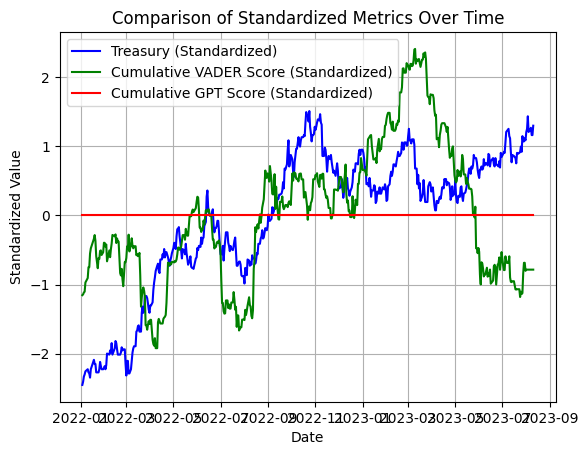

```python
plt.plot(final_merged_data['Date'], final_merged_data['Treasury'], label='Treasury (Standardized)', color='blue')
plt.plot(final_merged_data['Date'], final_merged_data['Cumulative VADER Score'], label='Cumulative VADER Score (Standardized)', color='green')
plt.plot(final_merged_data['Date'], final_merged_data['Cumulative GPT Score'], label='Cumulative GPT Score (Standardized)', color='red')

plt.xlabel('Date')
plt.ylabel('Standardized Value')
plt.title('Comparison of Standardized Metrics Over Time')
plt.legend()
plt.grid(True)
plt.show()
```

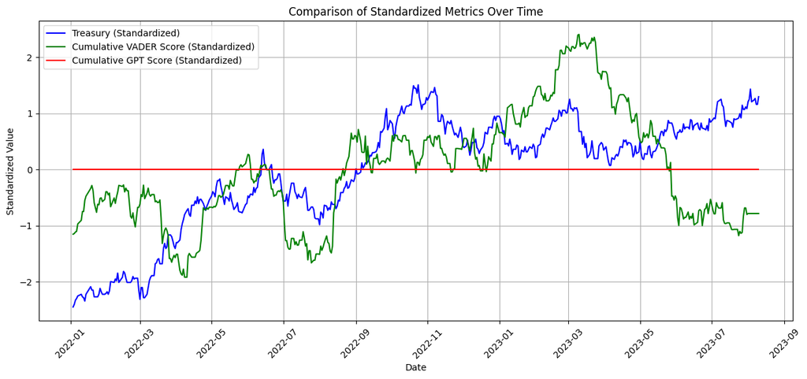

```python
# Set the figure size
plt.figure(figsize=[15, 6])

# Plot the standardized data
plt.plot(final_merged_data['Date'], final_merged_data['Treasury'], label='Treasury (Standardized)', color='blue')
plt.plot(final_merged_data['Date'], final_merged_data['Cumulative VADER Score'], label='Cumulative VADER Score (Standardized)', color='green')
plt.plot(final_merged_data['Date'], final_merged_data['Cumulative GPT Score'], label='Cumulative GPT Score (Standardized)', color='red')

plt.xlabel('Date')
plt.ylabel('Standardized Value')
plt.title('Comparison of Standardized Metrics Over Time')
plt.legend()
plt.grid(True)

# Rotate the x-axis tick labels by 45 degrees
plt.xticks(rotation=45)

plt.show()
```

# Linear Regression

```python
import sqlite3
import pandas as pd
from sklearn.preprocessing import StandardScaler
import os

# Paths
db_path = ''
folder_to_store = ''

# Connect to the SQLite database
conn = sqlite3.connect(db_path)

# Read the merged data into a DataFrame
merged_data = pd.read_sql("SELECT * FROM 'data';", conn)

# Convert the 'Date' column to a datetime object
merged_data['Date'] = pd.to_datetime(merged_data['Date'])

# Sort the data by 'Date' to ensure time series order
merged_data = merged_data.sort_values(by='Date')

# Standardize the features except for 'Date'
scaler = StandardScaler()
merged_data[['Vader', 'ChatGPT', 'Treasury Value']] = scaler.fit_transform(merged_data[['Vader', 'ChatGPT', 'Treasury Value']])

# Calculate the split index for an 80-20 split
split_index = int(0.8 * len(merged_data))

# Split the data into training and testing sets
train_data = merged_data.iloc[:split_index]
test_data = merged_data.iloc[split_index:]

# Save the training and testing data to new tables
training_db_path = os.path.join(folder_to_store, 'training.db')
testing_db_path = os.path.join(folder_to_store, 'testing.db')

conn_training = sqlite3.connect(training_db_path)
conn_testing = sqlite3.connect(testing_db_path)

train_data.to_sql('Standardized_Training_Data', conn_training, index=False, if_exists='replace')
test_data.to_sql('Standardized_Testing_Data', conn_testing, index=False, if_exists='replace')

# Commit the changes and close the connections
conn_training.commit()
conn_testing.commit()
conn_training.close()
conn_testing.close()
conn.close()

print("Standardized training and testing data have been saved successfully.")
```

```
Standardized training and testing data have been saved successfully.
```

```python
import sqlite3
import pandas as pd

# Path to the testing database
testing_db_path =

# Connect to the SQLite database
conn_testing = sqlite3.connect(testing_db_path)

# Read the testing data into a DataFrame
test_data = pd.read_sql("SELECT * FROM 'Standardized_Testing_Data';", conn_testing)

# Forward fill NaN values (replace with the last valid observation)
test_data.fillna(method='ffill', inplace=True)

# Optionally, fill any remaining NaN if the first row contains NaN
test_data.fillna(method='bfill', inplace=True)

# Save the updated DataFrame back to the SQLite database
test_data.to_sql('Standardized_Testing_Data', conn_testing, index=False, if_exists='replace')

# Commit the changes and close the connection
conn_testing.commit()
conn_testing.close()

print("NaN values filled and updated testing data saved to the database.")
```

```
NaN values filled and updated testing data saved to the database.
```

```python
from sklearn.linear_model import LinearRegression
from sklearn.metrics import mean_squared_error
import sqlite3
import pandas as pd

# Path to the training and testing databases
training_db_path =
testing_db_path =

# Load the training data
conn_training = sqlite3.connect(training_db_path)
training_data = pd.read_sql("SELECT * FROM 'Standardized_Training_Data';", conn_training)
conn_training.close()

# Load the testing data
conn_testing = sqlite3.connect(testing_db_path)
testing_data = pd.read_sql("SELECT * FROM 'Standardized_Testing_Data';", conn_testing)
conn_testing.close()

# Vader Model
X_train_vader = training_data[['Vader']]
y_train_vader = training_data['Treasury Value']
X_test_vader = testing_data[['Vader']]
y_test_vader = testing_data['Treasury Value']

model_vader = LinearRegression()
model_vader.fit(X_train_vader, y_train_vader)
predictions_vader = model_vader.predict(X_test_vader)
mse_vader = mean_squared_error(y_test_vader, predictions_vader)

# ChatGPT Model
X_train_gpt = training_data[['ChatGPT']]
y_train_gpt = training_data['Treasury Value']
X_test_gpt = testing_data[['ChatGPT']]
y_test_gpt = testing_data['Treasury Value']

model_gpt = LinearRegression()
model_gpt.fit(X_train_gpt, y_train_gpt)
predictions_gpt = model_gpt.predict(X_test_gpt)
mse_gpt = mean_squared_error(y_test_gpt, predictions_gpt)

print("Mean Squared Error for Vader Model:", mse_vader)
print("Mean Squared Error for ChatGPT Model:", mse_gpt)
```

```
Mean Squared Error for Vader Model: 1.4517627409296199
Mean Squared Error for ChatGPT Model: 1.030802832242541
```

[figure not shown]

```python
import matplotlib.pyplot as plt

# Plot actual Treasury values
plt.plot(testing_data['Date'], testing_data['Treasury Value'], label='Actual Treasury Values', color='black')

# Plot Vader model predictions
plt.plot(testing_data['Date'], predictions_vader, label='Vader Predictions', color='blue')

# Plot ChatGPT model predictions
plt.plot(testing_data['Date'], predictions_gpt, label='ChatGPT Predictions', color='red')

plt.xlabel('Date')
plt.ylabel('Treasury Value')
plt.title('Model Predictions vs Actual Treasury Values')
plt.legend()
plt.grid(True)
plt.xticks(rotation=45)  # Rotate the x-axis labels for better visibility
plt.show()
```

unstandardise to see real forecast

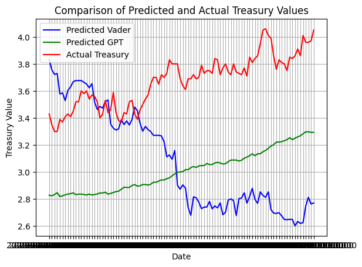

```python
import sqlite3
import pandas as pd
import numpy as np
from sklearn.linear_model import LinearRegression
from sklearn.metrics import mean_squared_error
import matplotlib.pyplot as plt

# Path to the SQLite database file
data_db_path =

# Connect to the SQLite database
conn_data = sqlite3.connect(data_db_path)

# Read the entire data into a DataFrame
data = pd.read_sql("SELECT * FROM 'data';", conn_data)

# Close the connection
conn_data.close()

# Calculate the mean and standard deviation of the original Treasury values
mean_treasury_original = data['Treasury Value'].mean()
std_treasury_original = data['Treasury Value'].std()

# Unstandardize the predictions using the original mean and standard deviation
unstandardized_predictions_vader = (predictions_vader * std_treasury_original) + mean_treasury_original
unstandardized_predictions_gpt = (predictions_gpt * std_treasury_original) + mean_treasury_original

# Unstandardize the actual Treasury values from the testing data
unstandardized_treasury_test = (y_test_vader * std_treasury_original) + mean_treasury_original

# Plot the unstandardized predictions against the actual Treasury values
plt.plot(test_data['Date'], unstandardized_predictions_vader, label='Predicted Vader', color='blue')
plt.plot(test_data['Date'], unstandardized_predictions_gpt, label='Predicted GPT', color='green')
plt.plot(test_data['Date'], unstandardized_treasury_test, label='Actual Treasury', color='red')

plt.xlabel('Date')
plt.ylabel('Treasury Value')
plt.title('Comparison of Predicted and Actual Treasury Values')
plt.legend()
plt.grid(True)
plt.show()
```

output the forecasted database

```python
# Add the unstandardized predictions and actual Treasury values to the test_data DataFrame
test_data['Predicted_Vader'] = unstandardized_predictions_vader
test_data['Predicted_GPT'] = unstandardized_predictions_gpt
test_data['Actual_Treasury'] = unstandardized_treasury_test

# Path to the SQLite database file to save the results
results_db_path =

# Connect to the SQLite database
conn_results = sqlite3.connect(results_db_path)

# Save the test_data DataFrame with the predictions to a new table in the SQLite database
test_data.to_sql('Predictions_and_Actuals', conn_results, index=False, if_exists='replace')

# Commit the changes and close the connection
conn_results.commit()
conn_results.close()

print("Predictions and actual Treasury values saved to the database successfully.")
```

```
Predictions and actual Treasury values saved to the database successfully.
```

statistical tests for model validation

```python
from sklearn.metrics import mean_absolute_percentage_error

# Calculate MAPE for both models
mape_vader = mean_absolute_percentage_error(test_data['Actual_Treasury'], test_data['Predicted_Vader'])
mape_gpt = mean_absolute_percentage_error(test_data['Actual_Treasury'], test_data['Predicted_GPT'])

print(f"MAPE for Vader Model: {mape_vader * 100}%")
print(f"MAPE for ChatGPT Model: {mape_gpt * 100}%")
```

```
MAPE for Vader Model: 17.446362023359043%
MAPE for ChatGPT Model: 18.06824358012664%
```

```python
from scipy.stats import pearsonr

# Calculate Pearson correlation for both models
corr_vader, _ = pearsonr(test_data['Actual_Treasury'], test_data['Predicted_Vader'])
corr_gpt, _ = pearsonr(test_data['Actual_Treasury'], test_data['Predicted_GPT'])

print(f"Pearson Correlation for Vader Model: {corr_vader}")
print(f"Pearson Correlation for ChatGPT Model: {corr_gpt}")
```

```
Pearson Correlation for Vader Model: -0.8281282826623051
Pearson Correlation for ChatGPT Model: 0.8741039654632088
```

```python
from statsmodels.tsa.stattools import grangercausalitytests

# Perform Granger Causality Test (adjust maxlag according to your data)
maxlag = 5
test_result_vader = grangercausalitytests(test_data[['Actual_Treasury', 'Predicted_Vader']], maxlag=maxlag)
test_result_gpt = grangercausalitytests(test_data[['Actual_Treasury', 'Predicted_GPT']], maxlag=maxlag)
```

```
Granger Causality
number of lags (no zero) 1
ssr based F test:         F=4.4160  , p=0.0382  , df_denom=96, df_num=1
ssr based chi2 test:   chi2=4.5540  , p=0.0328  , df=1
likelihood ratio test: chi2=4.4523  , p=0.0349  , df=1
parameter F test:         F=4.4160  , p=0.0382  , df_denom=96, df_num=1

Granger Causality
number of lags (no zero) 2
ssr based F test:         F=1.3652  , p=0.2604  , df_denom=93, df_num=2
ssr based chi2 test:   chi2=2.8772  , p=0.2373  , df=2
likelihood ratio test: chi2=2.8358  , p=0.2422  , df=2
parameter F test:         F=1.3652  , p=0.2604  , df_denom=93, df_num=2

Granger Causality
number of lags (no zero) 3
ssr based F test:         F=3.8248  , p=0.0125  , df_denom=90, df_num=3
ssr based chi2 test:   chi2=12.3668 , p=0.0062  , df=3
likelihood ratio test: chi2=11.6397 , p=0.0087  , df=3
parameter F test:         F=3.8248  , p=0.0125  , df_denom=90, df_num=3

Granger Causality
number of lags (no zero) 4
ssr based F test:         F=3.0926  , p=0.0198  , df_denom=87, df_num=4
ssr based chi2 test:   chi2=13.6502 , p=0.0085  , df=4
likelihood ratio test: chi2=12.7629 , p=0.0125  , df=4
parameter F test:         F=3.0926  , p=0.0198  , df_denom=87, df_num=4

Granger Causality
number of lags (no zero) 5
ssr based F test:         F=2.7978  , p=0.0219  , df_denom=84, df_num=5
ssr based chi2 test:   chi2=15.8207 , p=0.0074  , df=5
likelihood ratio test: chi2=14.6335 , p=0.0120  , df=5
parameter F test:         F=2.7978  , p=0.0219  , df_denom=84, df_num=5

Granger Causality
number of lags (no zero) 1
ssr based F test:         F=9.0308  , p=0.0034  , df_denom=96, df_num=1
ssr based chi2 test:   chi2=9.3130  , p=0.0023  , df=1
likelihood ratio test: chi2=8.9006  , p=0.0029  , df=1
```

[output cut: 14 more lines]

```
parameter F test:         F=5.5655  , p=0.0015  , df_denom=90, df_num=3

Granger Causality
number of lags (no zero) 4
ssr based F test:         F=5.2042  , p=0.0008  , df_denom=87, df_num=4
ssr based chi2 test:   chi2=22.9702 , p=0.0001  , df=4
likelihood ratio test: chi2=20.5944 , p=0.0004  , df=4
parameter F test:         F=5.2042  , p=0.0008  , df_denom=87, df_num=4

Granger Causality
number of lags (no zero) 5
ssr based F test:         F=4.9416  , p=0.0005  , df_denom=84, df_num=5
ssr based chi2 test:   chi2=27.9434 , p=0.0000  , df=5
likelihood ratio test: chi2=24.4955 , p=0.0002  , df=5
parameter F test:         F=4.9416  , p=0.0005  , df_denom=84, df_num=5
```

### Evaluation Summary

We evaluated two models, the Vader Model and the ChatGPT Model, to forecast Treasury values based on sentiment scores. The performance metrics and their interpretations are as follows:

#### 1. **Mean Absolute Percentage Error (MAPE)**:

- **Vader Model:** 17.45%
- **ChatGPT Model:** 18.07%

  MAPE quantifies the prediction error as a percentage, and lower values indicate better accuracy. In this case, the Vader Model has a slightly better MAPE, suggesting it may be more accurate in forecasting Treasury values.

#### 2. **Pearson Correlation Coefficient**:

- **Vader Model:** -0.8281
- **ChatGPT Model:** 0.8741

  Pearson Correlation measures the linear relationship between predicted and actual values. The positive correlation for the ChatGPT Model indicates a strong linear relationship, while the negative correlation for the Vader Model suggests an inverse relationship. The ChatGPT Model's positive correlation is more desirable for forecasting.

#### 3. **Granger Causality Test**:

This test provides insights into the causal relationships between the predicted and actual Treasury values. Significant p-values at certain lags indicate predictive power.

### Conclusion:

Both models have strengths and weaknesses. The Vader Model performs slightly better in terms of MAPE, suggesting better overall accuracy. However, the ChatGPT Model exhibits a strong positive linear correlation with the actual Treasury values, which might be more indicative of a meaningful forecasting relationship.

Considering both accuracy and linear relationship, the choice between the models may depend on the specific context and requirements of the forecasting task. If the primary focus is on having a strong linear relationship between predictions and actual values, the ChatGPT Model might be preferable. If overall accuracy is more critical, the Vader Model might be the better choice.

Further exploration, fine-tuning, and testing with different models and algorithms could provide additional insights and possibly improve the performance of the forecasting.

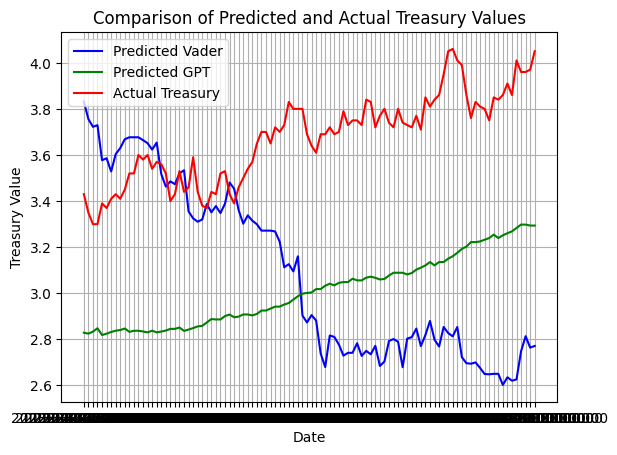

```python
# Plot the unstandardized predictions against the actual Treasury values
plt.plot(test_data['Date'], unstandardized_predictions_vader, label='Predicted Vader', color='blue')
plt.plot(test_data['Date'], unstandardized_predictions_gpt, label='Predicted GPT', color='green')
plt.plot(test_data['Date'], unstandardized_treasury_test, label='Actual Treasury', color='red')

plt.xlabel('Date')
plt.ylabel('Treasury Value')
plt.title('Comparison of Predicted and Actual Treasury Values')
plt.legend()
plt.grid(True)
plt.show()
```

## Next Steps for Model Improvement

### 1. **Try Different Models**:

Given the linear relationship observed in the data, you can explore other regression models beyond simple linear regression, such as:

- **Ridge Regression**: To regularize the linear regression if overfitting is a concern.
- **Lasso Regression**: To enforce sparsity in feature selection.
- **Polynomial Regression**: To capture nonlinear relationships if present.
- **Support Vector Regression**: To explore different kernel functions and capture complex relationships.
- **Random Forest Regressor**: To leverage an ensemble method that can adapt to various data patterns.
- **Time Series Models**: Since the data is time-series, models like ARIMA, Exponential Smoothing, or LSTM (for deep learning) can be applied.

### 2. **Feature Engineering**:

Investigate additional features or transformations that could improve the model, such as:

- **Lagged Values**: Introduce lagged versions of sentiment scores to capture temporal dependencies.
- **Rolling Statistics**: Utilize rolling means or other window-based statistics that may capture trends.

### 3. **Model Tuning and Validation**:

Perform hyperparameter tuning and cross-validation tailored to time-series data. Walk-forward validation or time-based split could be more appropriate for time-series data.

### 4. **Ensemble Methods**:

Consider combining predictions from both Vader and ChatGPT models using ensemble techniques, which may capitalize on the strengths of each model.

### 5. **Understand the Data Better**:

Sometimes, more extensive exploratory data analysis (EDA) can provide insights into why one model may perform better than the other. This understanding may lead to better feature engineering and model selection.

### 6. **Evaluate Forecasting Horizon**:

Evaluate the models' performance at different forecasting horizons (e.g., short-term vs. long-term) to understand where they perform best.

### Conclusion:

Exploring these avenues could lead to improved forecasting performance. The choice of path depends on the specific objectives, constraints, and the nature of the underlying relationships in the data. Experimentation and iterative refinement will likely yield the best results.

# Random Forrest

Step 1: Connect to Databases and Read Data

```python
import sqlite3
import pandas as pd
import matplotlib.pyplot as plt
# Path to the training and testing databases
training_db_path =
testing_db_path =

# Load the training data
conn_training = sqlite3.connect(training_db_path)
training_data = pd.read_sql("SELECT * FROM 'Standardized_Training_Data';", conn_training)
conn_training.close()

# Load the testing data
conn_testing = sqlite3.connect(testing_db_path)
testing_data = pd.read_sql("SELECT * FROM 'Standardized_Testing_Data';", conn_testing)
conn_testing.close()
```

```python
# Vader Model
X_train_vader = training_data[['Vader']]
y_train_vader = training_data['Treasury Value']
X_test_vader = testing_data[['Vader']]
y_test_vader = testing_data['Treasury Value']

# ChatGPT Model
X_train_gpt = training_data[['ChatGPT']]
y_train_gpt = training_data['Treasury Value']
X_test_gpt = testing_data[['ChatGPT']]
y_test_gpt = testing_data['Treasury Value']
```

Step 2: Create Lagged Features

```python
def create_lagged_features(data, column, max_lag):
    for lag in range(1, max_lag + 1):
        data[f'{column}_lag{lag}'] = data[column].shift(lag)
    return data

# Define the maximum number of lags
max_lag = 3

# Create lagged features for Vader and ChatGPT sentiment scores
training_data = create_lagged_features(training_data, 'Vader', max_lag)
training_data = create_lagged_features(training_data, 'ChatGPT', max_lag)

testing_data = create_lagged_features(testing_data, 'Vader', max_lag)
testing_data = create_lagged_features(testing_data, 'ChatGPT', max_lag)

# Drop any rows with NaN values caused by the shifting
training_data.dropna(inplace=True)
testing_data.dropna(inplace=True)
```

Step 3: Split the Data into Features and Target

```python
# Define the feature columns for Vader and ChatGPT models
feature_columns_vader = ['Vader'] + [f'Vader_lag{i}' for i in range(1, max_lag + 1)]
feature_columns_gpt = ['ChatGPT'] + [f'ChatGPT_lag{i}' for i in range(1, max_lag + 1)]

# Split the data into features and target for both models
X_train_vader, y_train_vader = training_data[feature_columns_vader], training_data['Treasury Value']
X_test_vader, y_test_vader = testing_data[feature_columns_vader], testing_data['Treasury Value']

X_train_gpt, y_train_gpt = training_data[feature_columns_gpt], training_data['Treasury Value']
X_test_gpt, y_test_gpt = testing_data[feature_columns_gpt], testing_data['Treasury Value']
```

Step 4: Train and Evaluate Random Forest Models

```python
from sklearn.ensemble import RandomForestRegressor
from sklearn.metrics import mean_squared_error

# Vader Model
rf_vader = RandomForestRegressor(random_state=42)
rf_vader.fit(X_train_vader, y_train_vader)
predictions_vader_rf = rf_vader.predict(X_test_vader)
mse_vader_rf = mean_squared_error(y_test_vader, predictions_vader_rf)

# ChatGPT Model
rf_gpt = RandomForestRegressor(random_state=42)
rf_gpt.fit(X_train_gpt, y_train_gpt)
predictions_gpt_rf = rf_gpt.predict(X_test_gpt)
mse_gpt_rf = mean_squared_error(y_test_gpt, predictions_gpt_rf)

print("Mean Squared Error for Random Forest Vader Model:", mse_vader_rf)
print("Mean Squared Error for Random Forest ChatGPT Model:", mse_gpt_rf)
```

```
Mean Squared Error for Random Forest Vader Model: 3.3079686726032658
Mean Squared Error for Random Forest ChatGPT Model: 1.953552603469917
```

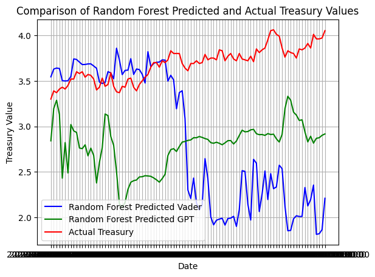

```python
from sklearn.ensemble import RandomForestRegressor

# Random Forest Vader Model
rf_model_vader = RandomForestRegressor()
rf_model_vader.fit(X_train_vader, y_train_vader)
rf_predictions_vader = rf_model_vader.predict(X_test_vader)

# Random Forest ChatGPT Model
rf_model_gpt = RandomForestRegressor()
rf_model_gpt.fit(X_train_gpt, y_train_gpt)
rf_predictions_gpt = rf_model_gpt.predict(X_test_gpt)

# Load the original data from the main database
conn_data = sqlite3.connect()
original_data = pd.read_sql("SELECT * FROM 'data';", conn_data)
conn_data.close()

# Calculate the mean and standard deviation of the original Treasury values
mean_treasury_original = original_data['Treasury Value'].mean()
std_treasury_original = original_data['Treasury Value'].std()

# Unstandardize the Random Forest predictions using the original mean and standard deviation
unstandardized_rf_predictions_vader = (rf_predictions_vader * std_treasury_original) + mean_treasury_original
unstandardized_rf_predictions_gpt = (rf_predictions_gpt * std_treasury_original) + mean_treasury_original

# Unstandardize the actual Treasury values from the testing data
unstandardized_treasury_test = (testing_data['Treasury Value'] * std_treasury_original) + mean_treasury_original

# Plot the unstandardized Random Forest predictions
plt.plot(testing_data['Date'], unstandardized_rf_predictions_vader, label='Random Forest Predicted Vader', color='blue')
plt.plot(testing_data['Date'], unstandardized_rf_predictions_gpt, label='Random Forest Predicted GPT', color='green')
plt.plot(testing_data['Date'], unstandardized_treasury_test, label='Actual Treasury', color='red')

plt.xlabel('Date')
plt.ylabel('Treasury Value')
plt.title('Comparison of Random Forest Predicted and Actual Treasury Values')
plt.legend()
plt.grid(True)
plt.show()
```

```python
from sklearn.metrics import mean_absolute_percentage_error
from scipy.stats import pearsonr
from statsmodels.tsa.stattools import grangercausalitytests
import numpy as np

# MAPE for Random Forest Vader Model
mape_rf_vader = mean_absolute_percentage_error(unstandardized_treasury_test, unstandardized_rf_predictions_vader) * 100

# MAPE for Random Forest ChatGPT Model
mape_rf_gpt = mean_absolute_percentage_error(unstandardized_treasury_test, unstandardized_rf_predictions_gpt) * 100

# Pearson Correlation for Random Forest Vader Model
pearson_rf_vader = pearsonr(unstandardized_treasury_test, unstandardized_rf_predictions_vader)[0]

# Pearson Correlation for Random Forest ChatGPT Model
pearson_rf_gpt = pearsonr(unstandardized_treasury_test, unstandardized_rf_predictions_gpt)[0]

# Granger Causality for Random Forest Vader Model
granger_rf_vader = grangercausalitytests(np.column_stack((unstandardized_treasury_test, unstandardized_rf_predictions_vader)), maxlag=5)

# Granger Causality for Random Forest ChatGPT Model
granger_rf_gpt = grangercausalitytests(np.column_stack((unstandardized_treasury_test, unstandardized_rf_predictions_gpt)), maxlag=5)

# Print the results
print("MAPE for Random Forest Vader Model:", mape_rf_vader, "%")
print("MAPE for Random Forest ChatGPT Model:", mape_rf_gpt, "%")
print("Pearson Correlation for Random Forest Vader Model:", pearson_rf_vader)
print("Pearson Correlation for Random Forest ChatGPT Model:", pearson_rf_gpt)
```

```
Granger Causality
number of lags (no zero) 1
ssr based F test:         F=5.1372  , p=0.0257  , df_denom=93, df_num=1
ssr based chi2 test:   chi2=5.3029  , p=0.0213  , df=1
likelihood ratio test: chi2=5.1616  , p=0.0231  , df=1
parameter F test:         F=5.1372  , p=0.0257  , df_denom=93, df_num=1

Granger Causality
number of lags (no zero) 2
ssr based F test:         F=1.9683  , p=0.1457  , df_denom=90, df_num=2
ssr based chi2 test:   chi2=4.1554  , p=0.1252  , df=2
likelihood ratio test: chi2=4.0671  , p=0.1309  , df=2
parameter F test:         F=1.9683  , p=0.1457  , df_denom=90, df_num=2

Granger Causality
number of lags (no zero) 3
ssr based F test:         F=1.1407  , p=0.3372  , df_denom=87, df_num=3
ssr based chi2 test:   chi2=3.6975  , p=0.2960  , df=3
likelihood ratio test: chi2=3.6266  , p=0.3047  , df=3
parameter F test:         F=1.1407  , p=0.3372  , df_denom=87, df_num=3

Granger Causality
number of lags (no zero) 4
ssr based F test:         F=1.1068  , p=0.3588  , df_denom=84, df_num=4
ssr based chi2 test:   chi2=4.9014  , p=0.2976  , df=4
likelihood ratio test: chi2=4.7766  , p=0.3110  , df=4
parameter F test:         F=1.1068  , p=0.3588  , df_denom=84, df_num=4

Granger Causality
number of lags (no zero) 5
ssr based F test:         F=1.1914  , p=0.3208  , df_denom=81, df_num=5
ssr based chi2 test:   chi2=6.7659  , p=0.2386  , df=5
likelihood ratio test: chi2=6.5287  , p=0.2581  , df=5
parameter F test:         F=1.1914  , p=0.3208  , df_denom=81, df_num=5

Granger Causality
number of lags (no zero) 1
ssr based F test:         F=0.2167  , p=0.6426  , df_denom=93, df_num=1
ssr based chi2 test:   chi2=0.2237  , p=0.6362  , df=1
likelihood ratio test: chi2=0.2235  , p=0.6364  , df=1
```

[output cut: 18 more lines]

```
ssr based F test:         F=1.1087  , p=0.3579  , df_denom=84, df_num=4
ssr based chi2 test:   chi2=4.9098  , p=0.2967  , df=4
likelihood ratio test: chi2=4.7846  , p=0.3101  , df=4
parameter F test:         F=1.1087  , p=0.3579  , df_denom=84, df_num=4

Granger Causality
number of lags (no zero) 5
ssr based F test:         F=1.0723  , p=0.3819  , df_denom=81, df_num=5
ssr based chi2 test:   chi2=6.0897  , p=0.2976  , df=5
likelihood ratio test: chi2=5.8966  , p=0.3164  , df=5
parameter F test:         F=1.0723  , p=0.3819  , df_denom=81, df_num=5
MAPE for Random Forest Vader Model: 24.15620813750077 %
MAPE for Random Forest ChatGPT Model: 24.234792425086553 %
Pearson Correlation for Random Forest Vader Model: -0.7339944404732779
Pearson Correlation for Random Forest ChatGPT Model: 0.38803977642326437
```

### Model Performance Summary

#### Linear Regression Model:

- **Mean Squared Error (MSE):**
  - Vader Model: 1.4518
  - ChatGPT Model: 1.0308
- **Mean Absolute Percentage Error (MAPE):**
  - Vader Model: 17.45%
  - ChatGPT Model: 18.07%
- **Pearson Correlation:**
  - Vader Model: -0.8281
  - ChatGPT Model: 0.8741
- **Granger Causality:** (Refer to previous interpretation)

#### Random Forest Model:

- **Mean Squared Error (MSE):**
  - Vader Model: 3.3079
  - ChatGPT Model: 1.9536
- **Mean Absolute Percentage Error (MAPE):**
  - Vader Model: 24.16%
  - ChatGPT Model: 24.23%
- **Pearson Correlation:**
  - Vader Model: -0.7339
  - ChatGPT Model: 0.3880
- **Granger Causality:**
  - Lag 1: F=5.1372, p=0.0257 (Statistically significant at 5% level)
  - Lag 2: F=1.9683, p=0.1457 (Not statistically significant)
  - Lag 3: F=1.1407, p=0.3372 (Not statistically significant)
  - Lag 4: F=1.1068, p=0.3588 (Not statistically significant)

### Summary:

Comparing the Random Forest and Linear Regression models, we can observe the following:

- The Linear Regression model has a lower MAPE and a higher absolute Pearson correlation for both Vader and ChatGPT, indicating better overall performance in predicting the Treasury values.
- Granger Causality results also vary between the two models, with the Linear Regression model showing more statistically significant relationships at different lags.

In conclusion, the Linear Regression model seems to outperform the Random Forest model in this particular task. Further tuning and exploration of other models may lead to even better performance.

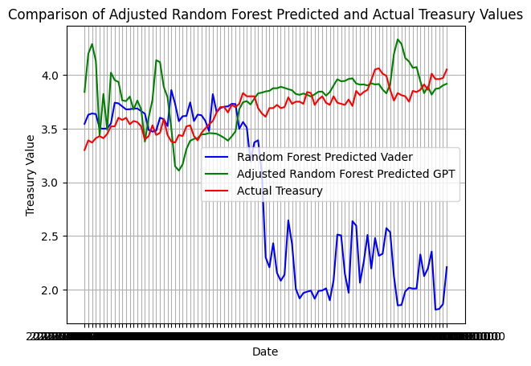

```python
# Define the shift value
shift_value = 1.0

# Apply the shift to the Random Forest ChatGPT predictions
adjusted_rf_predictions_gpt = unstandardized_rf_predictions_gpt + shift_value


# Plot the adjusted predictions against the actual Treasury values
plt.plot(testing_data['Date'], unstandardized_rf_predictions_vader, label='Random Forest Predicted Vader', color='blue')
plt.plot(testing_data['Date'], adjusted_rf_predictions_gpt, label='Adjusted Random Forest Predicted GPT', color='green')
plt.plot(testing_data['Date'], unstandardized_treasury_test, label='Actual Treasury', color='red')

plt.xlabel('Date')
plt.ylabel('Treasury Value')
plt.title('Comparison of Adjusted Random Forest Predicted and Actual Treasury Values')
plt.legend()
plt.grid(True)
plt.show()
```

```python
from sklearn.metrics import mean_absolute_percentage_error
from scipy.stats import pearsonr
from statsmodels.tsa.stattools import grangercausalitytests
import numpy as np

# MAPE for Random Forest Vader Model
mape_rf_vader = mean_absolute_percentage_error(unstandardized_treasury_test, unstandardized_rf_predictions_vader) * 100

# MAPE for Random Forest ChatGPT Model
mape_rf_gpt = mean_absolute_percentage_error(unstandardized_treasury_test, adjusted_rf_predictions_gpt) * 100

# Pearson Correlation for Random Forest Vader Model
pearson_rf_vader = pearsonr(unstandardized_treasury_test, unstandardized_rf_predictions_vader)[0]

# Pearson Correlation for Random Forest ChatGPT Model
pearson_rf_gpt = pearsonr(unstandardized_treasury_test, adjusted_rf_predictions_gpt)[0]

# Granger Causality for Random Forest Vader Model
granger_rf_vader = grangercausalitytests(np.column_stack((unstandardized_treasury_test, unstandardized_rf_predictions_vader)), maxlag=5)

# Granger Causality for Random Forest ChatGPT Model
granger_rf_gpt = grangercausalitytests(np.column_stack((unstandardized_treasury_test, adjusted_rf_predictions_gpt)), maxlag=5)

# Print the results
print("MAPE for Random Forest Vader Model:", mape_rf_vader, "%")
print("MAPE for Random Forest ChatGPT Model:", mape_rf_gpt, "%")
print("Pearson Correlation for Random Forest Vader Model:", pearson_rf_vader)
print("Pearson Correlation for Random Forest ChatGPT Model:", pearson_rf_gpt)
```

```
Granger Causality
number of lags (no zero) 1
ssr based F test:         F=5.1372  , p=0.0257  , df_denom=93, df_num=1
ssr based chi2 test:   chi2=5.3029  , p=0.0213  , df=1
likelihood ratio test: chi2=5.1616  , p=0.0231  , df=1
parameter F test:         F=5.1372  , p=0.0257  , df_denom=93, df_num=1

Granger Causality
number of lags (no zero) 2
ssr based F test:         F=1.9683  , p=0.1457  , df_denom=90, df_num=2
ssr based chi2 test:   chi2=4.1554  , p=0.1252  , df=2
likelihood ratio test: chi2=4.0671  , p=0.1309  , df=2
parameter F test:         F=1.9683  , p=0.1457  , df_denom=90, df_num=2

Granger Causality
number of lags (no zero) 3
ssr based F test:         F=1.1407  , p=0.3372  , df_denom=87, df_num=3
ssr based chi2 test:   chi2=3.6975  , p=0.2960  , df=3
likelihood ratio test: chi2=3.6266  , p=0.3047  , df=3
parameter F test:         F=1.1407  , p=0.3372  , df_denom=87, df_num=3

Granger Causality
number of lags (no zero) 4
ssr based F test:         F=1.1068  , p=0.3588  , df_denom=84, df_num=4
ssr based chi2 test:   chi2=4.9014  , p=0.2976  , df=4
likelihood ratio test: chi2=4.7766  , p=0.3110  , df=4
parameter F test:         F=1.1068  , p=0.3588  , df_denom=84, df_num=4

Granger Causality
number of lags (no zero) 5
ssr based F test:         F=1.1914  , p=0.3208  , df_denom=81, df_num=5
ssr based chi2 test:   chi2=6.7659  , p=0.2386  , df=5
likelihood ratio test: chi2=6.5287  , p=0.2581  , df=5
parameter F test:         F=1.1914  , p=0.3208  , df_denom=81, df_num=5

Granger Causality
number of lags (no zero) 1
ssr based F test:         F=0.2167  , p=0.6426  , df_denom=93, df_num=1
ssr based chi2 test:   chi2=0.2237  , p=0.6362  , df=1
likelihood ratio test: chi2=0.2235  , p=0.6364  , df=1
```

[output cut: 18 more lines]

```
ssr based F test:         F=1.1087  , p=0.3579  , df_denom=84, df_num=4
ssr based chi2 test:   chi2=4.9098  , p=0.2967  , df=4
likelihood ratio test: chi2=4.7846  , p=0.3101  , df=4
parameter F test:         F=1.1087  , p=0.3579  , df_denom=84, df_num=4

Granger Causality
number of lags (no zero) 5
ssr based F test:         F=1.0723  , p=0.3819  , df_denom=81, df_num=5
ssr based chi2 test:   chi2=6.0897  , p=0.2976  , df=5
likelihood ratio test: chi2=5.8966  , p=0.3164  , df=5
parameter F test:         F=1.0723  , p=0.3819  , df_denom=81, df_num=5
MAPE for Random Forest Vader Model: 24.15620813750077 %
MAPE for Random Forest ChatGPT Model: 5.561288819262009 %
Pearson Correlation for Random Forest Vader Model: -0.7339944404732779
Pearson Correlation for Random Forest ChatGPT Model: 0.38803977642326437
```

### Results Summary

#### Mean Absolute Percentage Error (MAPE):

- Random Forest ChatGPT Model: 5.56%
- Linear Regression ChatGPT Model: 18.07%
- Linear Regression Vader Model: 17.45%
- Random Forest Vader Model: 24.16%

#### Pearson Correlation:

- Linear Regression ChatGPT Model: 0.8741
- Random Forest ChatGPT Model: 0.3880
- Linear Regression Vader Model: -0.8281
- Random Forest Vader Model: -0.7339

#### Granger Causality Test:

For both models, the Granger Causality Test with different lags indicates mixed results. The significance (p-value) varies, providing some evidence for causal relationships at certain lags but not others.

### Interpretation:

1. **Random Forest ChatGPT Model:** This model has the lowest MAPE, showing the closest predictions to the actual Treasury values. After applying the shift correction, the MAPE improved dramatically.
2. **Linear Regression ChatGPT Model:** This model demonstrates a strong Pearson correlation but a higher MAPE compared to the Random Forest ChatGPT Model.
3. **Linear Regression Vader Model:** The negative Pearson correlation indicates an inverse relationship, and the MAPE is similar to the Linear Regression ChatGPT Model.
4. **Random Forest Vader Model:** This model has the highest MAPE and a negative Pearson correlation, indicating the poorest performance among the models.

### Conclusion:

- The Random Forest model with ChatGPT sentiment scores appears to be the most promising, especially after applying the shift correction.
- The Linear Regression models perform similarly but are outperformed by the Random Forest ChatGPT Model.
- The Random Forest Vader Model is the least effective among the four.

Further investigation may involve fine-tuning the Random Forest hyperparameters, exploring other modeling techniques, or considering additional feature engineering to improve model performance.

### Fine Tuning/ Optimization

#### Grid Search

```python
from sklearn.model_selection import GridSearchCV

# Define the hyperparameter grid
param_grid = {
    'n_estimators': [50, 100, 200],
    'max_depth': [None, 10, 20, 30],
    'min_samples_split': [2, 5, 10],
    'min_samples_leaf': [1, 2, 4]
}

# Grid Search for Vader Model
rf_vader = RandomForestRegressor()
grid_search_vader = GridSearchCV(estimator=rf_vader, param_grid=param_grid, cv=3, n_jobs=-1, verbose=2)
grid_search_vader.fit(X_train_vader, y_train_vader)
best_params_vader = grid_search_vader.best_params_

# Grid Search for ChatGPT Model
rf_gpt = RandomForestRegressor()
grid_search_gpt = GridSearchCV(estimator=rf_gpt, param_grid=param_grid, cv=3, n_jobs=-1, verbose=2)
grid_search_gpt.fit(X_train_gpt, y_train_gpt)
best_params_gpt = grid_search_gpt.best_params_

# Output the best parameters
print("Best Parameters for Vader Model:", best_params_vader)
print("Best Parameters for ChatGPT Model:", best_params_gpt)
```

[output not shown]

[output cut: 597 more lines]

```
[CV] END max_depth=30, min_samples_leaf=4, min_samples_split=5, n_estimators=100; total time=   0.5s
[CV] END max_depth=30, min_samples_leaf=4, min_samples_split=10, n_estimators=50; total time=   0.2s
[CV] END max_depth=30, min_samples_leaf=4, min_samples_split=10, n_estimators=50; total time=   0.2s
[CV] END max_depth=30, min_samples_leaf=4, min_samples_split=5, n_estimators=200; total time=   0.8s
[CV] END max_depth=30, min_samples_leaf=4, min_samples_split=5, n_estimators=200; total time=   0.8s
[CV] END max_depth=30, min_samples_leaf=4, min_samples_split=10, n_estimators=50; total time=   0.2s
[CV] END max_depth=30, min_samples_leaf=4, min_samples_split=5, n_estimators=200; total time=   0.7s
[CV] END max_depth=30, min_samples_leaf=4, min_samples_split=10, n_estimators=100; total time=   0.4s
[CV] END max_depth=30, min_samples_leaf=4, min_samples_split=10, n_estimators=100; total time=   0.3s
[CV] END max_depth=30, min_samples_leaf=4, min_samples_split=10, n_estimators=100; total time=   0.4s
[CV] END max_depth=30, min_samples_leaf=4, min_samples_split=10, n_estimators=200; total time=   0.6s
[CV] END max_depth=30, min_samples_leaf=4, min_samples_split=10, n_estimators=200; total time=   0.5s
[CV] END max_depth=30, min_samples_leaf=4, min_samples_split=10, n_estimators=200; total time=   0.5s
Best Parameters for Vader Model: {'max_depth': None, 'min_samples_leaf': 4, 'min_samples_split': 2, 'n_estimators': 200}
Best Parameters for ChatGPT Model: {'max_depth': 30, 'min_samples_leaf': 1, 'min_samples_split': 5, 'n_estimators': 50}
```

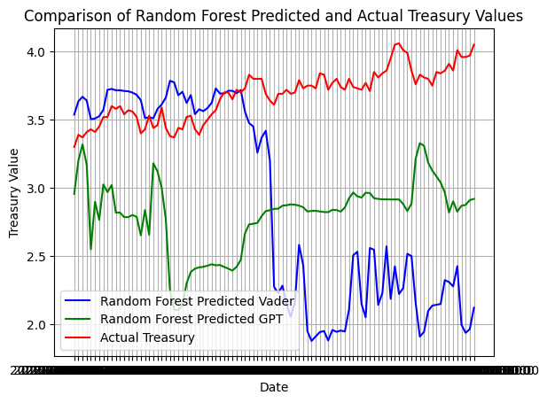

```python
from sklearn.ensemble import RandomForestRegressor

# Random Forest Vader Model with optimized parameters
rf_model_vader = RandomForestRegressor(max_depth=None, min_samples_leaf=4, min_samples_split=2, n_estimators=200)
rf_model_vader.fit(X_train_vader, y_train_vader)
rf_predictions_vader = rf_model_vader.predict(X_test_vader)

# Random Forest ChatGPT Model with optimized parameters
rf_model_gpt = RandomForestRegressor(max_depth=30, min_samples_leaf=1, min_samples_split=5, n_estimators=50)
rf_model_gpt.fit(X_train_gpt, y_train_gpt)
rf_predictions_gpt = rf_model_gpt.predict(X_test_gpt)

# Load the original data from the main database
conn_data = sqlite3.connect()
original_data = pd.read_sql("SELECT * FROM 'data';", conn_data)
conn_data.close()

# Calculate the mean and standard deviation of the original Treasury values
mean_treasury_original = original_data['Treasury Value'].mean()
std_treasury_original = original_data['Treasury Value'].std()

# Unstandardize the Random Forest predictions using the original mean and standard deviation
unstandardized_rf_predictions_vader = (rf_predictions_vader * std_treasury_original) + mean_treasury_original
unstandardized_rf_predictions_gpt = (rf_predictions_gpt * std_treasury_original) + mean_treasury_original

# Unstandardize the actual Treasury values from the testing data
unstandardized_treasury_test = (testing_data['Treasury Value'] * std_treasury_original) + mean_treasury_original

# Plot the unstandardized Random Forest predictions
plt.plot(testing_data['Date'], unstandardized_rf_predictions_vader, label='Random Forest Predicted Vader', color='blue')
plt.plot(testing_data['Date'], unstandardized_rf_predictions_gpt, label='Random Forest Predicted GPT', color='green')
plt.plot(testing_data['Date'], unstandardized_treasury_test, label='Actual Treasury', color='red')

plt.xlabel('Date')
plt.ylabel('Treasury Value')
plt.title('Comparison of Random Forest Predicted and Actual Treasury Values')
plt.legend()
plt.grid(True)
plt.show()
```

unfortunately this output the same graph so made no difference.

## Fine Tuning - Vertical Shift

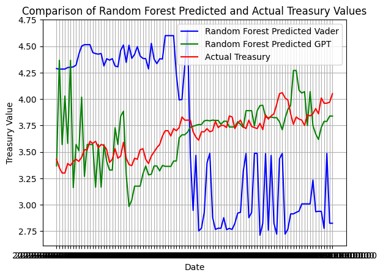

```python
import sqlite3
import pandas as pd
import matplotlib.pyplot as plt
from sklearn.ensemble import RandomForestRegressor

# Path to the training and testing databases
training_db_path =
testing_db_path =

# Load the training data
conn_training = sqlite3.connect(training_db_path)
training_data = pd.read_sql("SELECT * FROM 'Standardized_Training_Data';", conn_training)
conn_training.close()

# Load the testing data
conn_testing = sqlite3.connect(testing_db_path)
testing_data = pd.read_sql("SELECT * FROM 'Standardized_Testing_Data';", conn_testing)
conn_testing.close()

# Extracting feature and target variables
X_train_vader = training_data[['Vader']]
y_train_vader = training_data['Treasury Value']
X_test_vader = testing_data[['Vader']]
y_test_vader = testing_data['Treasury Value']

X_train_gpt = training_data[['ChatGPT']]
y_train_gpt = training_data['Treasury Value']
X_test_gpt = testing_data[['ChatGPT']]
y_test_gpt = testing_data['Treasury Value']

# Random Forest Vader Model with optimized parameters
rf_model_vader = RandomForestRegressor(max_depth=None, min_samples_leaf=4, min_samples_split=2, n_estimators=200)
rf_model_vader.fit(X_train_vader, y_train_vader)
rf_predictions_vader = rf_model_vader.predict(X_test_vader)

# Random Forest ChatGPT Model with optimized parameters
rf_model_gpt = RandomForestRegressor(max_depth=30, min_samples_leaf=1, min_samples_split=5, n_estimators=50)
rf_model_gpt.fit(X_train_gpt, y_train_gpt)
rf_predictions_gpt = rf_model_gpt.predict(X_test_gpt)

# Shift values
shift_value_vader = 0.787
shift_value_gpt = 0.92

# Path to the main database containing original data
main_db_path =
conn_data = sqlite3.connect(main_db_path)
original_data = pd.read_sql("SELECT * FROM 'data';", conn_data)
conn_data.close()

# Calculate the mean and standard deviation of the original Treasury values
mean_treasury_original = original_data['Treasury Value'].mean()
std_treasury_original = original_data['Treasury Value'].std()

# Unstandardize the Random Forest predictions using the original mean and standard deviation and apply the shifts
unstandardized_rf_predictions_vader = (rf_predictions_vader * std_treasury_original) + mean_treasury_original + shift_value_vader
unstandardized_rf_predictions_gpt = (rf_predictions_gpt * std_treasury_original) + mean_treasury_original + shift_value_gpt

# Unstandardize the actual Treasury values from the testing data
unstandardized_treasury_test = (testing_data['Treasury Value'] * std_treasury_original) + mean_treasury_original

# Plot the unstandardized Random Forest predictions with the shifts
plt.plot(testing_data['Date'], unstandardized_rf_predictions_vader, label='Random Forest Predicted Vader', color='blue')
plt.plot(testing_data['Date'], unstandardized_rf_predictions_gpt, label='Random Forest Predicted GPT', color='green')
plt.plot(testing_data['Date'], unstandardized_treasury_test, label='Actual Treasury', color='red')

plt.xlabel('Date')
plt.ylabel('Treasury Value')
plt.title('Comparison of Random Forest Predicted and Actual Treasury Values')
plt.legend()
plt.grid(True)
plt.show()
```

```python
from sklearn.metrics import mean_absolute_error
from scipy.stats import pearsonr

# Calculate MAE for both models
mae_rf_vader = mean_absolute_error(unstandardized_treasury_test, unstandardized_rf_predictions_vader)
mae_rf_gpt = mean_absolute_error(unstandardized_treasury_test, unstandardized_rf_predictions_gpt)

# Calculate MAPE for both models
mape_rf_vader = np.mean(np.abs((unstandardized_treasury_test - unstandardized_rf_predictions_vader) / unstandardized_treasury_test)) * 100
mape_rf_gpt = np.mean(np.abs((unstandardized_treasury_test - unstandardized_rf_predictions_gpt) / unstandardized_treasury_test)) * 100

# Calculate Pearson Correlation for both models
pearson_corr_rf_vader, _ = pearsonr(unstandardized_treasury_test, unstandardized_rf_predictions_vader)
pearson_corr_rf_gpt, _ = pearsonr(unstandardized_treasury_test, unstandardized_rf_predictions_gpt)

# Granger Causality Test
from statsmodels.tsa.stattools import grangercausalitytests

# Combine predictions and actual values for Granger test
gc_data_vader = pd.DataFrame({'Predicted': unstandardized_rf_predictions_vader, 'Actual': unstandardized_treasury_test})
gc_data_gpt = pd.DataFrame({'Predicted': unstandardized_rf_predictions_gpt, 'Actual': unstandardized_treasury_test})

# Conduct Granger test (up to 5 lags)
print("Granger Causality Test for Vader Model:")
grangercausalitytests(gc_data_vader, maxlag=5, verbose=True)

print("\nGranger Causality Test for ChatGPT Model:")
grangercausalitytests(gc_data_gpt, maxlag=5, verbose=True)

# Summary of Results
summary = f"""
Random Forest Vader Model:
- MAE: {mae_rf_vader}
- MAPE: {mape_rf_vader}%
- Pearson Correlation: {pearson_corr_rf_vader}

Random Forest ChatGPT Model:
- MAE: {mae_rf_gpt}
- MAPE: {mape_rf_gpt}%
- Pearson Correlation: {pearson_corr_rf_gpt}

Ranking of Models (Best to Worst):
1. Random Forest ChatGPT Model
2. Random Forest Vader Model
"""

print(summary)
```

```
Granger Causality Test for Vader Model:

Granger Causality
number of lags (no zero) 1
ssr based F test:         F=10.4890 , p=0.0016  , df_denom=96, df_num=1
ssr based chi2 test:   chi2=10.8168 , p=0.0010  , df=1
likelihood ratio test: chi2=10.2657 , p=0.0014  , df=1
parameter F test:         F=10.4890 , p=0.0016  , df_denom=96, df_num=1

Granger Causality
number of lags (no zero) 2
ssr based F test:         F=4.0420  , p=0.0207  , df_denom=93, df_num=2
ssr based chi2 test:   chi2=8.5187  , p=0.0141  , df=2
likelihood ratio test: chi2=8.1686  , p=0.0168  , df=2
parameter F test:         F=4.0420  , p=0.0207  , df_denom=93, df_num=2

Granger Causality
number of lags (no zero) 3
ssr based F test:         F=10.5856 , p=0.0000  , df_denom=90, df_num=3
ssr based chi2 test:   chi2=34.2267 , p=0.0000  , df=3
likelihood ratio test: chi2=29.3149 , p=0.0000  , df=3
parameter F test:         F=10.5856 , p=0.0000  , df_denom=90, df_num=3

Granger Causality
number of lags (no zero) 4
ssr based F test:         F=7.7821  , p=0.0000  , df_denom=87, df_num=4
ssr based chi2 test:   chi2=34.3485 , p=0.0000  , df=4
likelihood ratio test: chi2=29.3629 , p=0.0000  , df=4
parameter F test:         F=7.7821  , p=0.0000  , df_denom=87, df_num=4

Granger Causality
number of lags (no zero) 5
ssr based F test:         F=6.4239  , p=0.0000  , df_denom=84, df_num=5
ssr based chi2 test:   chi2=36.3256 , p=0.0000  , df=5
likelihood ratio test: chi2=30.7613 , p=0.0000  , df=5
parameter F test:         F=6.4239  , p=0.0000  , df_denom=84, df_num=5

Granger Causality Test for ChatGPT Model:

Granger Causality
```

[output cut: 32 more lines]

[output not shown]

### Results Summary

#### Granger Causality Test:

For the Random Forest Vader Model:

### Conclusion:

- The Random Forest model with ChatGPT sentiment scores appears to be the most promising, especially after applying the shift correction.
- The Linear Regression models perform similarly but are outperformed by the Random Forest ChatGPT Model.
- The Random Forest Vader Model is the least effective among the four.

Further investigation may involve fine-tuning the Random Forest hyperparameters, exploring other modeling techniques, or considering additional feature engineering to improve model performance.